# Autocorrelación

Repositorio = https://github.com/jpospinalo/time-series

## 1. Cargue en un dataframe el archivo aus_producto.csv disponible en este repositorio. Filtre los valores con fechas iguales o superiores al año 2000 para la columna “Beer” y visualice la serie de tiempo. ¿Se observa comportamiento estacional, cíclico y tendencia?

## 2. Realice un diagrama de dispersión para los datos filtrados de la columna “Beer” contra su primer retraso. Visualice los valores de cada trimestre en diferentes colores Recuerde ubicar en el eje horizontal al retraso y en el vertical al valor actual. ¿Qué conclusiones podemos obtener a partir del gráfico?

## 3. Repita el procedimiento anterior, pero ahora genere gráficas para los 9 primeros retrasos de la columna “Beer”. No olvide visualizar cada trimestre en colores diferentes. Los nueve gráficos deben generarse en una matriz de 3 x 3. ¿Qué conclusiones podemos obtener a partir del gráfico?

## 4. Obtenga los valores de autocorrelación para los 9 retrasos del punto anterior y visualice el diagrama de autocorrelación. ¿Podemos identificar tendencia y estacionalidad en el gráfico de autocorrelación? Verifique si es posible y en caso de serlo consulte cómo hacerlo.

## 5. Cargue en un dataframe el archivo us_employment.csv disponible en este repositorio. Filtre los valores con fechas superiores al año 1980 y en los cuales el valor de la columna “Title” es “Retail Trade”. Visualice la serie de tiempo. ¿Se observa comportamiento estacional, cíclico y tendencia?

## 6. Obtenga los valores de autocorrelación para los 48 retrasos del punto anterior y visualice el diagrama de autocorrelación. ¿Es posible identificar tendencia y estacionalidad en el gráfico de autocorrelación?

## 7. Cargue en un dataframe el archivo gafa_stock.csv disponible en este repositorio. Filtre los valores de las acciones de Google en el año 2015 y visualice la serie de tiempo con los precios de cierre. ¿Se observa comportamiento estacional, cíclico y tendencia?

## 8. Obtenga los valores de autocorrelación para los primeros 100 retrasos del punto anterior y visualice el diagrama de autocorrelación. ¿Es posible identificar tendencia y estacionalidad en el gráfico de autocorrelación?

## 9. Cargue el conjunto de datos aus_arrivals.csv disponible en este repositorio comprende llegadas internacionales trimestrales a Australia desde Japón, Nueva Zelanda, Reino Unido y Estados Unidos. Visualice la serie de tiempo, el gráfico estacional y el “subseries plot” para comparar las diferencias entre las llegadas de estos cuatro países.

## 10. Cada una de las siguientes series de tiempo corresponde a alguno de los gráficos autocorrelación que se presentan a continuación. Su tarea es hacer coincidir cada serie de tiempo

[figure not shown]

```python
!pip install statsmodels
```

```
     ━━━━━━━━━━━━━━━━━━━━━━━━━━━━━━━━━━━━━━━ 10.8/10.8 MB 111.9 MB/s eta 0:00:00
     ━━━━━━━━━━━━━━━━━━━━━━━━━━━━━━━━━━━━━━ 233.9/233.9 kB 60.9 MB/s eta 0:00:00
```

```python
import pandas as pd
import matplotlib.pyplot as plt
from statsmodels.tsa.seasonal import seasonal_decompose
from statsmodels.graphics.tsaplots import plot_acf, plot_pacf,quarter_plot
import seaborn as sns
```

```python
# Punto 1

ruta_archivo = 'https://raw.githubusercontent.com/jpospinalo/time-series/main/aus_production.csv'

# Cargar el CSV en un DataFrame
df = pd.read_csv(ruta_archivo)

df.head()
```

|  | Unnamed: 0 | Quarter | Beer | Tobacco | Bricks | Cement | Electricity | Gas |
| --- | --- | --- | --- | --- | --- | --- | --- | --- |
| 0 | 1 | 1956 Q1 | 284 | 5225.0 | 189.0 | 465 | 3923 | 5 |
| 1 | 2 | 1956 Q2 | 213 | 5178.0 | 204.0 | 532 | 4436 | 6 |
| 2 | 3 | 1956 Q3 | 227 | 5297.0 | 208.0 | 561 | 4806 | 7 |
| 3 | 4 | 1956 Q4 | 308 | 5681.0 | 197.0 | 570 | 4418 | 6 |
| 4 | 5 | 1957 Q1 | 262 | 5577.0 | 187.0 | 529 | 4339 | 5 |

```python
# Transformar cuartiles a el primer mes correspondiente a dicho trimestre

df['QuarterDate'] = df['Quarter'].replace({
    'Q1': '-01-01',  # Enero
    'Q2': '-04-01',  # Abril
    'Q3': '-07-01',  # Julio
    'Q4': '-10-01'   # Octubre
}, regex=True)
```

```python
# Crear una nueva columna 'Fecha' y convertirla a datetime
df['Fecha'] = pd.to_datetime(df['QuarterDate'])
```

```python
# Eliminar columna 'QuarterDate' (Sobra por ser una copia de 'Quarter')
df.drop('QuarterDate', axis=1, inplace=True)
```

```python
# Filtrar los datos desde el año 2000
df2000 = df[df['Fecha'].dt.year >= 2000]

# Setear la columna 'Fecha' y 'Beer' como el índice
serieBeer = df2000.set_index('Fecha')['Beer']
```

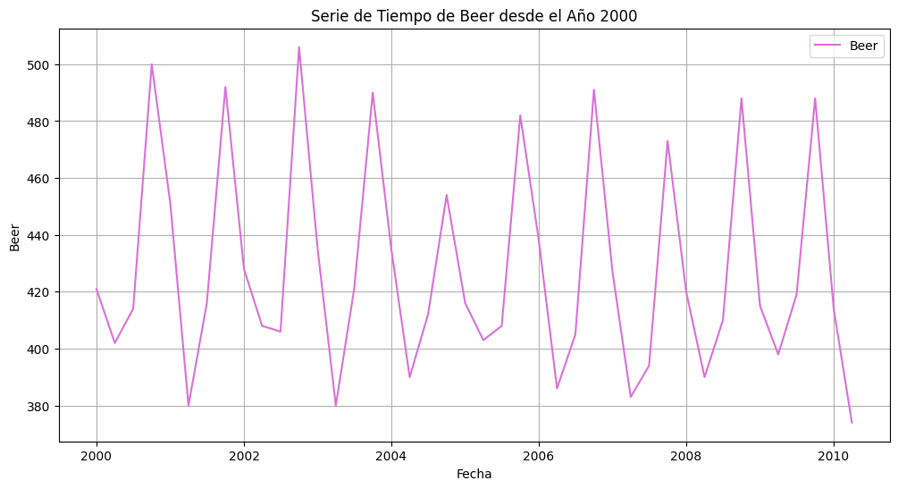

```python
plt.figure(figsize=(12, 6))
plt.plot(serieBeer, label='Beer', color='orchid')
plt.title('Serie de Tiempo de Beer desde el Año 2000')
plt.xlabel('Fecha')
plt.ylabel('Beer')
plt.legend()
plt.grid(True)
plt.show()
```

- En cuando a una tendencia, no se puede observar claramente a largo plazo si hay una tendencia positiva o negativa, si se mira anualmente, podria llegarse a ver una tendencia positiva o negativa, dependiendo el año, sin embargo, como se comentaba anteriormente, no se puede observar claramente a largo plazo.
- En cuanto a la ciclicidad, se puede observar claramente este comportamiento a lo largo de la serie de tiempo, en un periodo de dos años, se puede observar dos subidas o picos bastantes altos y una bajada o pico bastante bajo y esto se repite en toda la serie de tiempo.
- La estacionalidad puede verse dado el patron de subidas y bajadas y como este se repite a lo largo de cada año. Se ve que a medida que avanzan los meses del año, aumenta considerablemente el consumo de beer, esto tiene sentido gracias a que a medida de que se acercan fiestas (diciembre, navidad, fin de año, vacaciones, etc.) el consumo de beer aumenta bastante y es en esta epoca del año en donde se encuentran los picos más altos. Por otro lado, luego de fiestas y terminar invierno, el consumo de beer, disminuye significativamente, puesto que empiezan de nuevo las universidades y trabajos y la gente vuelve a tener un consumo bastante bajo de beer.

```python
# Punto 2
df2000['Beer_Lag'] = df2000['Beer'].shift(1)
```

```python
# Eliminar las filas con valores NaN
df2000 = df2000.dropna(subset=['Beer', 'Beer_Lag'])
```

```python
colores_trimestre = {'Q1': 'red', 'Q2': 'blue', 'Q3': 'green', 'Q4': 'orange'}
df2000['Color'] = df2000['Quarter'].str[-2:].map(colores_trimestre)
```

```python
df2000.head()
```

|  | Unnamed: 0 | Quarter | Beer | Tobacco | Bricks | Cement | Electricity | Gas | Fecha | Beer_Lag | Color |
| --- | --- | --- | --- | --- | --- | --- | --- | --- | --- | --- | --- |
| 177 | 178 | 2000 Q2 | 402 | 4860.0 | 447.0 | 2070 | 50670 | 199 | 2000-04-01 | 421.0 | blue |
| 178 | 179 | 2000 Q3 | 414 | 5185.0 | 421.0 | 1898 | 52623 | 213 | 2000-07-01 | 402.0 | green |
| 179 | 180 | 2000 Q4 | 500 | 4763.0 | 379.0 | 1652 | 49350 | 173 | 2000-10-01 | 414.0 | orange |
| 180 | 181 | 2001 Q1 | 451 | 4217.0 | 304.0 | 1554 | 51658 | 177 | 2001-01-01 | 500.0 | red |
| 181 | 182 | 2001 Q2 | 380 | 4959.0 | 337.0 | 1717 | 51103 | 205 | 2001-04-01 | 451.0 | blue |

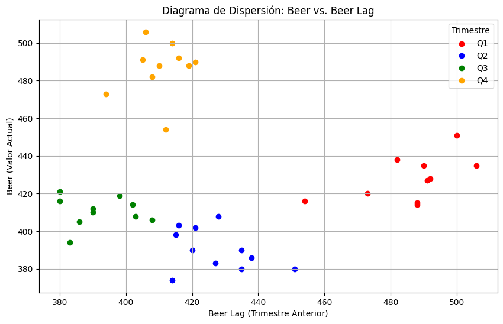

```python
plt.figure(figsize=(10, 6))

# Crear el scatter plot
for trimestre, color in colores_trimestre.items():
    subset = df2000[df2000['Quarter'].str.endswith(trimestre)]
    plt.scatter(subset['Beer_Lag'], subset['Beer'], color=color, label=trimestre)

plt.title('Diagrama de Dispersión: Beer vs. Beer Lag')
plt.xlabel('Beer Lag (Trimestre Anterior)')
plt.ylabel('Beer (Valor Actual)')
plt.legend(title='Trimestre')
plt.grid(True)
plt.show()
```

```python
# Punto 3

# Crear los lags de 1 a 9 trimestres
for i in range(1, 10):
    df2000[f'Lag_{i}'] = df2000['Beer'].shift(i)
```

```python
df2000[['Color', 'Quarter']].head(4)
```

|  | Color | Quarter |
| --- | --- | --- |
| 177 | blue | 2000 Q2 |
| 178 | green | 2000 Q3 |
| 179 | orange | 2000 Q4 |
| 180 | red | 2001 Q1 |

[figure not shown]

```python
# Configuración de la figura
fig, axes = plt.subplots(3, 3, figsize=(15, 15))
#           Q1      Q2      Q3        Q4
colores = ['red', 'blue', 'green', 'orange']

# Crear cada gráfico
for i, ax in enumerate(axes.flatten(), start=1):
    # Plot de los valores actuales contra el lag
    trimestre_colores = [colores[mes // 3] for mes in df2000['Fecha'].dt.month]
    ax.scatter(df2000[f'Lag_{i}'], df2000[f'Beer'], c=trimestre_colores, alpha=0.5)
    ax.set_title(f'Beer vs Lag {i}')
    ax.set_xlabel('Beer')
    ax.set_ylabel(f'Lag {i}')
    ax.grid(True)


plt.tight_layout()
plt.show()
```

```python
# Correlacion de cada una de las variables
correlaciones = []
for i in range(1, 10):
    correlacion = df2000['Beer'].corr(df2000[f'Lag_{i}'])
    correlaciones.append((f'Lag_{i}', correlacion))

# Mostrar las correlaciones
for lag, correlacion in correlaciones:
    print(f'Correlación Beer vs {lag}: {correlacion:.2f}')
```

```
Correlación Beer vs Lag_1: -0.06
Correlación Beer vs Lag_2: -0.79
Correlación Beer vs Lag_3: -0.02
Correlación Beer vs Lag_4: 0.91
Correlación Beer vs Lag_5: -0.10
Correlación Beer vs Lag_6: -0.77
Correlación Beer vs Lag_7: 0.01
Correlación Beer vs Lag_8: 0.90
Correlación Beer vs Lag_9: -0.12
```

```python
#           Q1      Q2      Q3        Q4
# colores = ['red', 'blue', 'green', 'orange']
```

### Beer vs Lag 1:

- Se muestra una dispersion sin un patron claro, esto se fortalece gracias a la baja correlación con la que cuenta (-0.06: casi nula). Lo que indica que la produccion de beer en un trimestre no tiene relación significativa con el trimestre inmediatamente anterior.
- Se puede observar una estacionalidad, puesto que los cuartiles Q1 y Q4 se encuentran en la parte mas alta del grafico, a diferencia de los cuartiles Q2 y Q3, esto se relaciona con lo dicho anteriormente, los meses en donde hay fiestas y vacaciones, el consumo de beer es mucho mayor a cuando no hay periodos vacacionales.

### Beer vs Lag 2:

- Se observa una fuerte correlación negativa (-0.79: fuerte negativa), esto sugiere que la produccion de beer fue alta hace dos semestres, es decir, la produccion de beer actual con respecto a un retraso de dos semestres, indica la peor produccion y mas baja de toda la serie.

### Beer vs Lag 4:

- Se observa una fuerte correlacion positiva, siendo de 0.91, la correlación más fuerte en toda la serie de tiempo, esto sugiere que la produccion de cerveza tiene un ciclo anual, indicando que los valores de produccion hace 4 trimestres son muy buenos predictores de los valores actuales. Es por esto que, en el grafico se muestran los datos agrupados a lo largo de una diagonal ascendente hacia la derecha.

### Beer vs Lag 5:

- La correlaciones es ligeramente negativa (-0.10), mostrando que no hay un patron evidente, e indicando que hace 5 trimestres hay poca relacion con la produccion actual de beer.

### Beer vs Lag 6:

- La correlacion es la segunda más baja en toda la serie de tiempo, siendo de -0.77, siendo muy similar a el retraso , indicando que despues de una produccion bastante grande de beer, la produccion disminuye hasta llegar a su punto más bajo, siendo este equivalente a un retraso de 6 trimestres. Adicionalmente, puede sugerir un patron ciclico, ya que, este patron se viene evidenciando desde el retraso 2, en donde se presentó otra correlacion fuerte negativa. Los puntos en el diagrama muestran una diagonal descendente hacia la izquierda.

### Beer vs Lag 7:

- En este punto, la correlación es casi nula (0.01), lo que indica que la producción de beer hace 7 trimestres no esta relacionada con la produccion actual de beer.

### Beer vs Lag 8:

- Al igual que el retraso 4, este grafico muestra una correlacion muy fuerte positiva. Indicando que cada dos años, la produccion de cerveza en ese tiempo puede ser un muy buen predictor de la produccion actual de beer.

### Beer vs Lag 9:

- Nuevamente, vuelve a disminuir considerablemente la correlacion, siendo para este caso una ligeramente negativa, la dispersion no muestra un patron claro, pero se espera que para el retraso 10, vuelva a los niveles de correlacion y de posible prediccion más bajos en la serie.

## En general

```python
# Punto 4

# Calcular la autocorrelación para los primeros 9 lags
autocorr_values = [serieBeer.autocorr(lag=i) for i in range(0, 10)]
print("Valores de autocorrelación:", autocorr_values)
```

```
Valores de autocorrelación: [0.9999999999999998, -0.0545670031002945, -0.7859353610961413, -0.02829083041072424, 0.9035249946958314, -0.08734749442671409, -0.7697655849135306, 0.0014666180527126123, 0.9040656143458601, -0.11329930043415821]
```

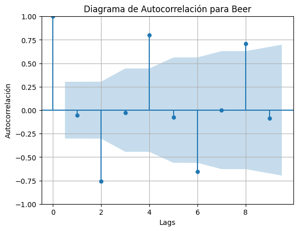

```python
# Graficar el diagrama de autocorrelación
plt.figure(figsize=(10, 6))
plot_acf(serieBeer, lags=9)
plt.title("Diagrama de Autocorrelación para Beer")
plt.xlabel("Lags")
plt.ylabel("Autocorrelación")
plt.grid(True)
plt.show()
```

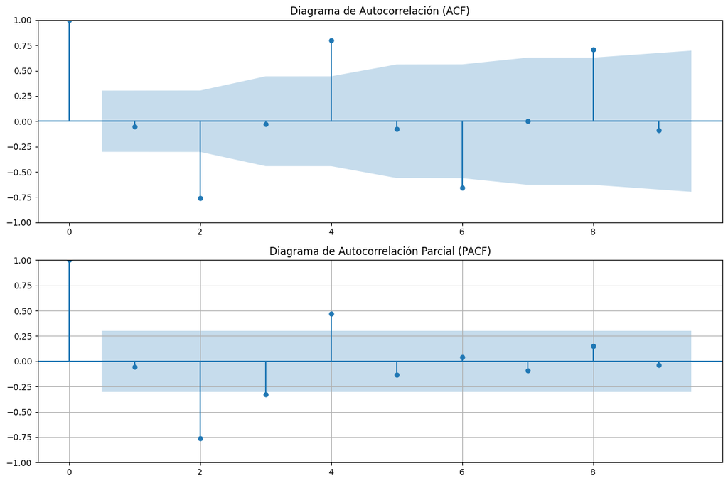

```python
fig, axes = plt.subplots(2, 1, figsize=(12, 8))

# Diagrama ACF
plot_acf(serieBeer, lags=9, ax=axes[0])
axes[0].set_title("Diagrama de Autocorrelación (ACF)")

# Diagrama PACF
plot_pacf(serieBeer, lags=9, method='ywm', ax=axes[1])
axes[1].set_title("Diagrama de Autocorrelación Parcial (PACF)")

plt.grid(True)
plt.tight_layout()
plt.show()
```

```python
# Punto 5

ruta_archivo = 'https://raw.githubusercontent.com/jpospinalo/time-series/main/us_employment.csv'

# Cargar el CSV en un DataFrame
df_us_employment = pd.read_csv(ruta_archivo)

df_us_employment.drop(columns=['Unnamed: 0'], inplace=True)

df_us_employment.head()
```

|  | Month | Series_ID | Title | Employed |
| --- | --- | --- | --- | --- |
| 0 | 1939 Jan | CEU0500000001 | Total Private | 25338.0 |
| 1 | 1939 Feb | CEU0500000001 | Total Private | 25447.0 |
| 2 | 1939 Mar | CEU0500000001 | Total Private | 25833.0 |
| 3 | 1939 Apr | CEU0500000001 | Total Private | 25801.0 |
| 4 | 1939 May | CEU0500000001 | Total Private | 26113.0 |

```python
# Trasformar la columna 'Month' en un objeto de tipo 'datetime'
df_us_employment['Date'] = pd.to_datetime(df_us_employment['Month'], format='%Y %b')

# Filtrar los datos para el año 1980 y el título 'Retail Trade'
df_us_employment_filtered = df_us_employment[(df_us_employment['Date'].dt.year > 1980) & (df_us_employment['Title'] == 'Retail Trade')]

df_us_employment_filtered.isnull().sum()
```

```
Month        0
Series_ID    0
Title        0
Employed     0
Date         0
dtype: int64
```

```python
df_us_employment_filtered.head()
```

|  | Month | Series_ID | Title | Employed | Date |
| --- | --- | --- | --- | --- | --- |
| 49923 | 1981 Jan | CEU4200000001 | Retail Trade | 10169.4 | 1981-01-01 |
| 49924 | 1981 Feb | CEU4200000001 | Retail Trade | 10065.0 | 1981-02-01 |
| 49925 | 1981 Mar | CEU4200000001 | Retail Trade | 10106.6 | 1981-03-01 |
| 49926 | 1981 Apr | CEU4200000001 | Retail Trade | 10272.9 | 1981-04-01 |
| 49927 | 1981 May | CEU4200000001 | Retail Trade | 10377.4 | 1981-05-01 |

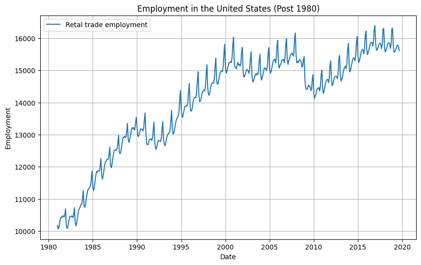

```python
plt.figure(figsize=(10, 6))
plt.plot(df_us_employment_filtered['Date'], df_us_employment_filtered['Employed'], label = 'Retal trade employment')
plt.title('Employment in the United States (Post 1980)')
plt.xlabel('Date')
plt.ylabel('Employment')
plt.legend()
plt.grid(True)
plt.show()
```

- Se observa un comportamiento estacional, ya que durante los primeros mese del año la cantidad de empleo disminuye, pero ya para finales de año este disminuye, esto se puede deber a que a fin de año por festividades el empleo aumenta, adicional se evidencia un comportamiento cíclico ya que este patrón se repite cada año, y por ultimo muestra una tendencia a la alta, puede ser por muchos factores pero por nombrar uno puede ser el constante desarrollo comercial o el crecimiento de la población.

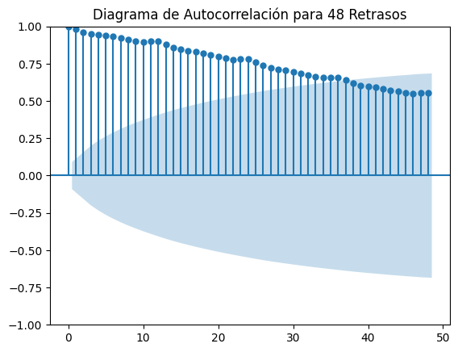

```python
# Punto 6

plt.figure(figsize=(10, 6))
plot_acf(df_us_employment_filtered['Employed'], lags=48)
plt.title("Diagrama de Autocorrelación para 48 Retrasos")
plt.show()
```

- Se puede observar una tendencia puesto que los valores en la autocorrelacion va disminuyendo poco a poco, esta es una caracteristica de que se pueda identificar una tendencia, y como se muestra en la anterior grafica, concuerdan los valores.
- Por otra parte, que los valores inicien fuera del indice de confianza, tambien refuerza esta idea.

```python
# Punto 7
ruta_archivo = 'https://raw.githubusercontent.com/jpospinalo/time-series/main/gafa_stock.csv'

# Cargar el CSV en un DataFrame
gafaStock = pd.read_csv(ruta_archivo)

gafaStock.head()
```

|  | Unnamed: 0 | Symbol | Date | Open | High | Low | Close | Adj_Close | Volume |
| --- | --- | --- | --- | --- | --- | --- | --- | --- | --- |
| 0 | 1 | AAPL | 2014-01-02 | 79.382858 | 79.575714 | 78.860001 | 79.018570 | 66.964325 | 58671200.0 |
| 1 | 2 | AAPL | 2014-01-03 | 78.980003 | 79.099998 | 77.204285 | 77.282860 | 65.493416 | 98116900.0 |
| 2 | 3 | AAPL | 2014-01-06 | 76.778572 | 78.114288 | 76.228569 | 77.704285 | 65.850533 | 103152700.0 |
| 3 | 4 | AAPL | 2014-01-07 | 77.760002 | 77.994286 | 76.845711 | 77.148575 | 65.379593 | 79302300.0 |
| 4 | 5 | AAPL | 2014-01-08 | 76.972855 | 77.937141 | 76.955711 | 77.637146 | 65.793633 | 64632400.0 |

```python
# Convertir a datetime
gafaStock['Date'] = pd.to_datetime(gafaStock['Date'])
```

```python
gafaStock.head()
```

|  | Unnamed: 0 | Symbol | Date | Open | High | Low | Close | Adj_Close | Volume |
| --- | --- | --- | --- | --- | --- | --- | --- | --- | --- |
| 0 | 1 | AAPL | 2014-01-02 | 79.382858 | 79.575714 | 78.860001 | 79.018570 | 66.964325 | 58671200.0 |
| 1 | 2 | AAPL | 2014-01-03 | 78.980003 | 79.099998 | 77.204285 | 77.282860 | 65.493416 | 98116900.0 |
| 2 | 3 | AAPL | 2014-01-06 | 76.778572 | 78.114288 | 76.228569 | 77.704285 | 65.850533 | 103152700.0 |
| 3 | 4 | AAPL | 2014-01-07 | 77.760002 | 77.994286 | 76.845711 | 77.148575 | 65.379593 | 79302300.0 |
| 4 | 5 | AAPL | 2014-01-08 | 76.972855 | 77.937141 | 76.955711 | 77.637146 | 65.793633 | 64632400.0 |

```python
# Filtrar por aciones de google en el 2015
google2015 = gafaStock[(gafaStock['Symbol'] == 'GOOG') & (gafaStock['Date'].dt.year == 2015)]
```

```python
google2015.head()
```

|  | Unnamed: 0 | Symbol | Date | Open | High | Low | Close | Adj_Close | Volume |
| --- | --- | --- | --- | --- | --- | --- | --- | --- | --- |
| 4026 | 4027 | GOOG | 2015-01-02 | 526.114746 | 528.362366 | 521.231628 | 521.937744 | 521.937744 | 1447600.0 |
| 4027 | 4028 | GOOG | 2015-01-05 | 520.396240 | 521.460388 | 510.252045 | 511.057617 | 511.057617 | 2059800.0 |
| 4028 | 4029 | GOOG | 2015-01-06 | 512.181458 | 513.350037 | 498.307800 | 499.212799 | 499.212799 | 2899900.0 |
| 4029 | 4030 | GOOG | 2015-01-07 | 504.225220 | 504.467896 | 496.915436 | 498.357513 | 498.357513 | 2065100.0 |
| 4030 | 4031 | GOOG | 2015-01-08 | 495.264526 | 500.724487 | 488.312805 | 499.928864 | 499.928864 | 3353600.0 |

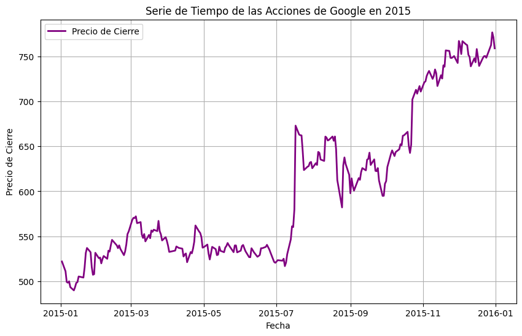

```python
plt.figure(figsize=(10, 6))
plt.plot(google2015['Date'], google2015['Close'], color='purple', linewidth=2, label='Precio de Cierre')
plt.title('Serie de Tiempo de las Acciones de Google en 2015')
plt.xlabel('Fecha')
plt.ylabel('Precio de Cierre')
plt.grid(True)
plt.legend()
plt.show()
```

- Se observa una tendencia clara en el año, esta tendencia es positiva y aumenta bastante a lo largo de toda la serie. Se encuentran diversas subidas y caidas en las aciones, sin embargo se evidencia un salto bastante grande en el mes de julio y agosto. En este tiempo, ocurrieron varias cosas en google para que sus acciones salgan disparadas en este mes en especifico. El 10 de agosto de 2015 google se convierte en la principal subsidiaria de Alphabet, ademas de que a lo largo de este año, tambien google se cambio de logo y se fundo youtube kids. Todas estas acciones, concuerdan con la fuerte subida en el precio de las aciones de google a lo largo del año 2015
- No se observa una clara estacionalidad, debido a que no hay un periodo del año que se espere que las acciones de google puedan subir o bajar, las acciones que se puedan haber realizado a lo largo de ese año, es lo que denota si las acciones suben o bajan de precio, y estas acciones, al no ser estacionarias y no hacerse siempre en el mismo punto, no se puede predecir, por ende, no se presencia estacionalidad en el grafico.
- Por otra parte, tampoco se evidencia una ciclicidad, debido a que la cantidad de datos no permiten poder analizar esta variable, y a su vez, en la serie de tiempo no se observan ni subidas ni bajadas de forma continua a lo largo de toda la serie de tiempo, es por esto que tampoco es ciclica.

```python
# Punto 8

# Filtrar los precios de cierre en 2015
lagClosePrices = google2015['Close']
lagClosePrices.head()
```

```
4026    521.937744
4027    511.057617
4028    499.212799
4029    498.357513
4030    499.928864
Name: Close, dtype: float64
```

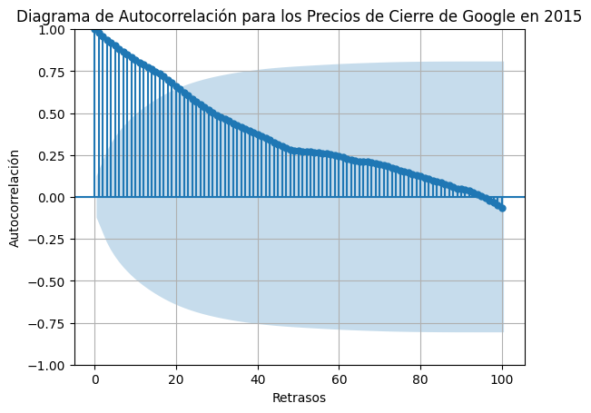

```python
plt.figure(figsize=(12, 6))
plot_acf(lagClosePrices, lags=100, alpha=0.05)
plt.title('Diagrama de Autocorrelación para los Precios de Cierre de Google en 2015')
plt.xlabel('Retrasos')
plt.ylabel('Autocorrelación')
plt.grid(True)
plt.show()
```

```python
# Crear los lags de 100 trimestres
for i in range(1, 100):
    google2015[f'Lag_{i}'] = google2015['Close'].shift(i)
```

[output not shown]

[output cut: 545 more lines]

[output not shown]

```python
# Correlacion de cada una de las variables
correlaciones = []
for i in range(1, 10):
    correlacion = google2015['Close'].corr(google2015[f'Lag_{i}'])
    correlaciones.append((f'Lag_{i}', correlacion))

# Mostrar las correlaciones
for lag, correlacion in correlaciones:
    print(f'Correlación Close vs {lag}: {correlacion:.2f}')
```

```
Correlación Close vs Lag_1: 0.99
Correlación Close vs Lag_2: 0.98
Correlación Close vs Lag_3: 0.97
Correlación Close vs Lag_4: 0.96
Correlación Close vs Lag_5: 0.95
Correlación Close vs Lag_6: 0.95
Correlación Close vs Lag_7: 0.94
Correlación Close vs Lag_8: 0.93
Correlación Close vs Lag_9: 0.92
```

```python
# Punto 9

ruta_archivo = 'https://raw.githubusercontent.com/jpospinalo/time-series/main/aus_arrivals.csv'

# Cargar el CSV en un DataFrame
arrivals = pd.read_csv(ruta_archivo)

arrivals.head()
```

|  | Unnamed: 0 | Quarter | Origin | Arrivals |
| --- | --- | --- | --- | --- |
| 0 | 1 | 1981 Q1 | Japan | 14763 |
| 1 | 2 | 1981 Q2 | Japan | 9321 |
| 2 | 3 | 1981 Q3 | Japan | 10166 |
| 3 | 4 | 1981 Q4 | Japan | 19509 |
| 4 | 5 | 1982 Q1 | Japan | 17117 |

```python
# Transformar cuartiles a el primer mes correspondiente a dicho trimestre

arrivals['QuarterDate'] = arrivals['Quarter'].replace({
    'Q1': '-01-01',  # Enero
    'Q2': '-04-01',  # Abril
    'Q3': '-07-01',  # Julio
    'Q4': '-10-01'   # Octubre
}, regex=True)
```

```python
# Crear una nueva columna 'Fecha' y convertirla a datetime
arrivals['Fecha'] = pd.to_datetime(arrivals['QuarterDate'])
```

```python
# Eliminar columna 'QuarterDate' (Sobra por ser una copia de 'Quarter')
arrivals.drop('QuarterDate', axis=1, inplace=True)
```

```python
arrivals.head()
```

|  | Unnamed: 0 | Quarter | Origin | Arrivals | Fecha |
| --- | --- | --- | --- | --- | --- |
| 0 | 1 | 1981 Q1 | Japan | 14763 | 1981-01-01 |
| 1 | 2 | 1981 Q2 | Japan | 9321 | 1981-04-01 |
| 2 | 3 | 1981 Q3 | Japan | 10166 | 1981-07-01 |
| 3 | 4 | 1981 Q4 | Japan | 19509 | 1981-10-01 |
| 4 | 5 | 1982 Q1 | Japan | 17117 | 1982-01-01 |

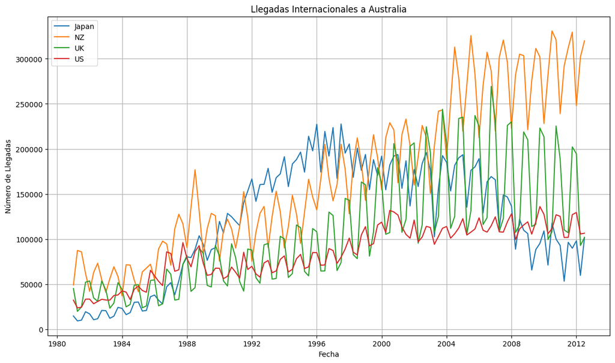

```python
plt.figure(figsize=(14, 8))

# Filtrar y graficar para cada país
for country in ['Japan', 'NZ', 'UK', 'US']:
    # Filtrar los datos por país
    country_data = arrivals[arrivals['Origin'] == country]

    # Graficar la serie de tiempo
    plt.plot(country_data['Fecha'], country_data['Arrivals'], label=country)

# Títulos y leyendas
plt.title('Llegadas Internacionales a Australia')
plt.xlabel('Fecha')
plt.ylabel('Número de Llegadas')
plt.legend()

# Mostrar el gráfico
plt.grid(True)
plt.show()
```

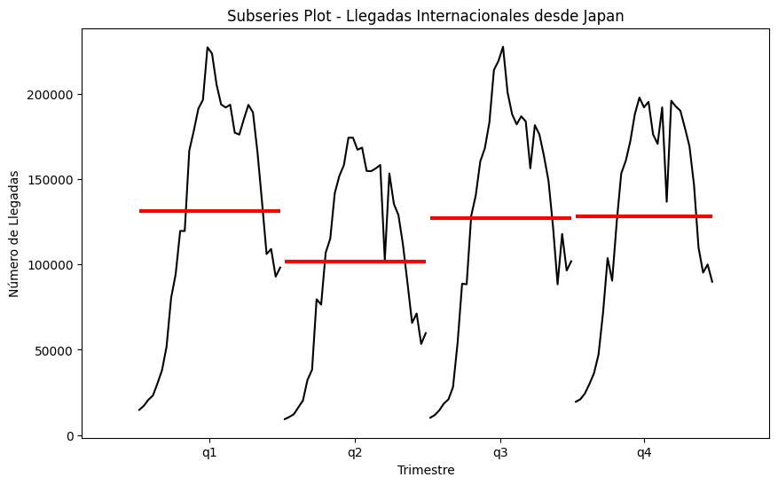

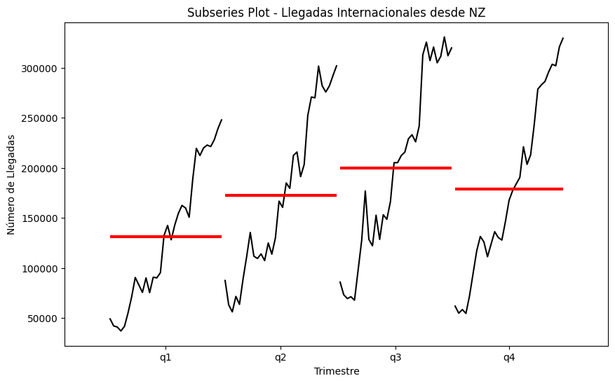

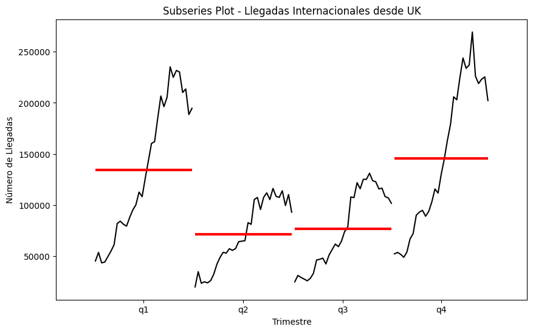

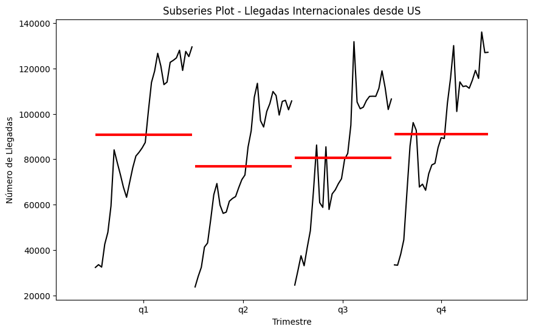

```python
arrivals.set_index('Fecha', inplace=True)

# Generar el subseries plot para cada país
plt.figure(figsize=(14, 8))
for country in ['Japan', 'NZ', 'UK', 'US']:
    # Filtrar los datos por país
    country_data = arrivals[arrivals['Origin'] == country]

    # Realizar el subseries plot
    plt.figure(figsize=(10, 6))
    quarter_plot(country_data['Arrivals'], ax=plt.gca())

    # Títulos y leyendas
    plt.title(f'Subseries Plot - Llegadas Internacionales desde {country}')
    plt.xlabel('Trimestre')
    plt.ylabel('Número de Llegadas')

# Mostrar los gráficos
plt.show()
```

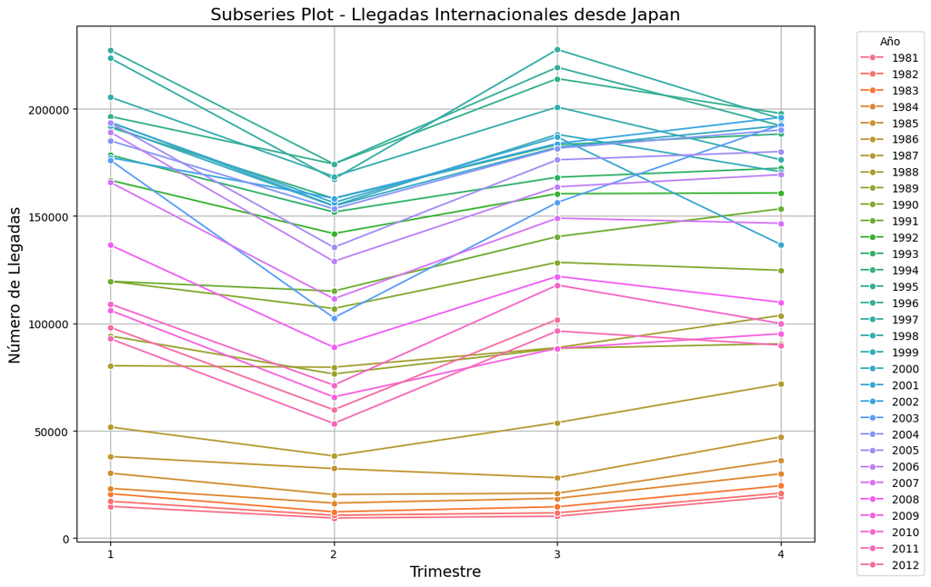

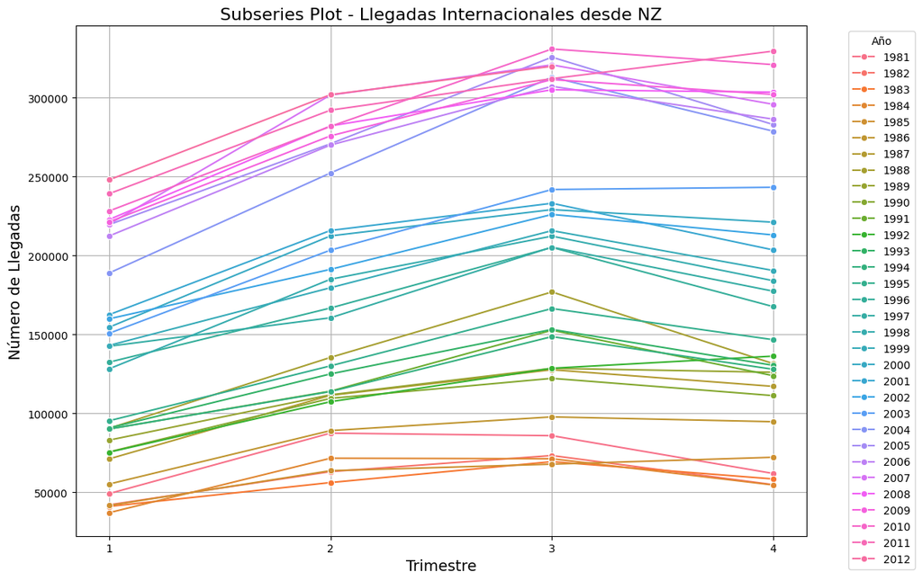

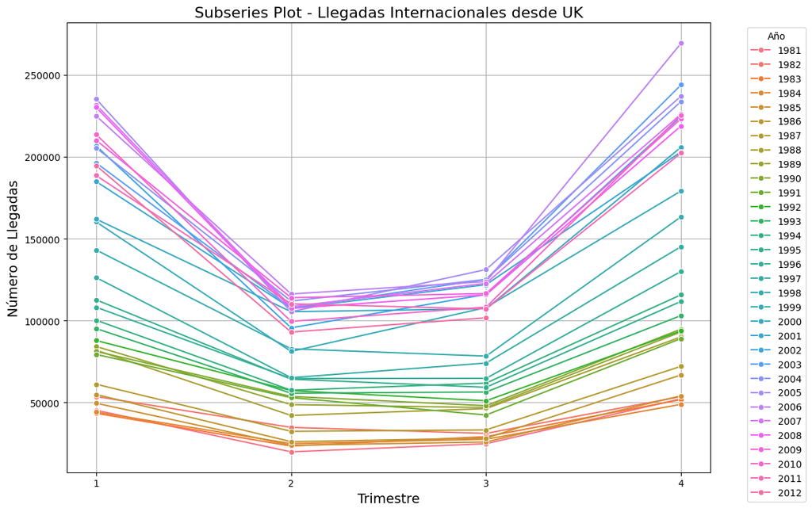

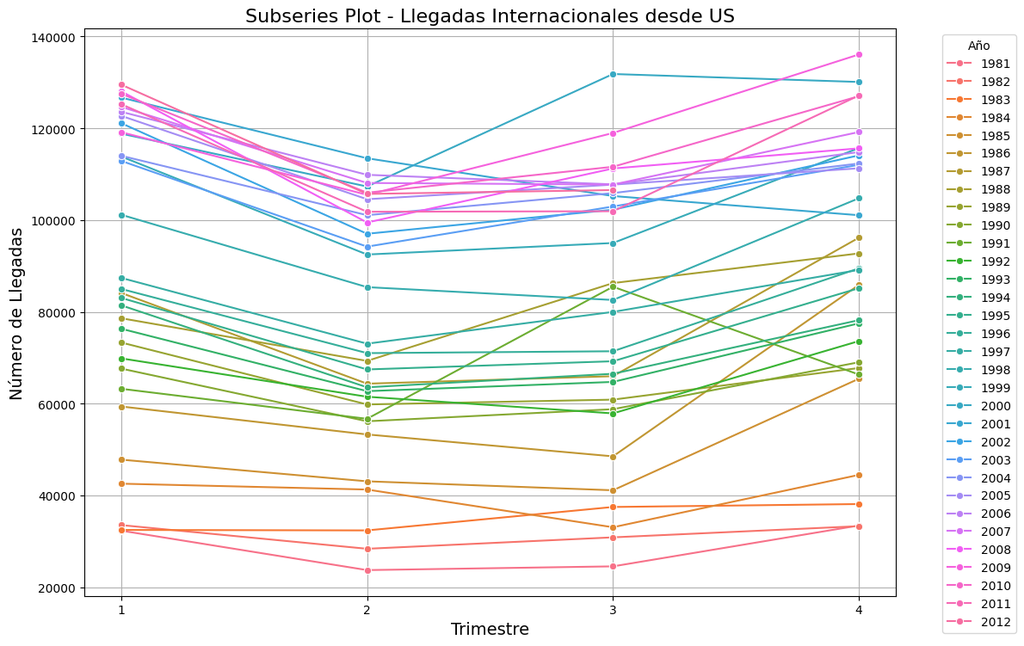

```python
arrivals.reset_index(inplace=True)  # Reseteamos el índice por si fue establecido previamente
arrivals['Fecha'] = pd.to_datetime(arrivals['Fecha'])  # Aseguramos el formato datetime
arrivals.set_index('Fecha', inplace=True)

# Extraer el año y el trimestre de la fecha
arrivals['Year'] = arrivals.index.year
arrivals['Quarter'] = arrivals.index.quarter

# Definir una paleta de colores
palette = sns.color_palette("husl", len(arrivals['Year'].unique()))

# Generar el subseries plot utilizando seaborn
for country in ['Japan', 'NZ', 'UK', 'US']:
    # Filtrar los datos por país
    country_data = arrivals[arrivals['Origin'] == country]

    plt.figure(figsize=(12, 8))
    sns.lineplot(
        data=country_data,
        x='Quarter',
        y='Arrivals',
        hue='Year',
        marker='o',
        palette=palette
    )

    # Configurar los ejes y títulos
    plt.title(f'Subseries Plot - Llegadas Internacionales desde {country}', fontsize=16)
    plt.xlabel('Trimestre', fontsize=14)
    plt.ylabel('Número de Llegadas', fontsize=14)
    plt.xticks([1, 2, 3, 4])
    plt.legend(title='Año', bbox_to_anchor=(1.05, 1), loc='upper left')
    plt.grid(True)
    plt.tight_layout()

    # Mostrar el gráfico
    plt.show()
```

[figure not shown]

Punto 10

- Serie de tiempo 1 con diagrama de autocorrelación A

No se ve tendencia clara, hay cambios constantes y aleatorios

- Serie de tiempo 2 con diagrama de autocorrelación B

Presenta una estacionalidad, no hay grandes fluctuaciones ni cambios aleatroios

- Serie de tiempo 3 con diagrama de autocorrelación D

Muestra una tendencia positiva y estacionalidad por periodos

- Serie de tiempo 4 con diagrama de autocorrelación C

Muestra una estacionalidad con picos periodicamente, es la que más concuerda por los datos que estan anualmente.

[figure not shown]